Activity One: SES (1 hour) Run this code and get a feel for what it is doing. Feel free to change it up and just learn by playing.

```r
#install.packages("fpp")
library(fpp)
```

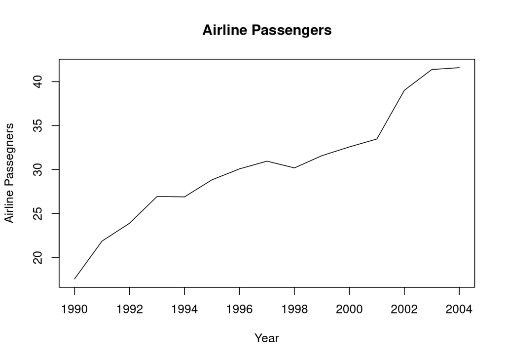

```r
# 1. SES MODEL FOR AUS AIR
data(ausair)

#returns a ts object
air = window(ausair, start = 1990, end = 2004)

# Always plot the data first!
plot(air,ylab = "Airline Passegners", xlab = "Year", main = "Airline Passengers")
```

```r
#fit 3 different simple exponential smoothing models ... how are they different?
# what does the h paramter do?
fit1 = ses(air, initial = "simple",alpha = .2,h = 3)
fit2 = ses(air,initial = "simple",alpha = .6, h = 3)
fit3 = ses(air, h = 3) #defaults

# the forecast package has a nice accuracy funciton with various metrics just pass it the
# the model and the data!  (This is the "training" data)
accuracy(fit1, ausair)
```

```
##                     ME      RMSE       MAE      MPE     MAPE     MASE
## Training set  5.864549  6.301705  5.864549 18.74164 18.74164 3.199632
## Test set     11.632265 11.751057 11.632265 24.77018 24.77018 6.346433
##                      ACF1 Theil's U
## Training set  0.405609699        NA
## Test set     -0.003569265  6.140567
```

```r
accuracy(fit2, ausair)
```

```
##                    ME     RMSE      MAE       MPE      MAPE     MASE
## Training set 2.576335 3.101549 2.582686  8.507273  8.528313 1.409084
## Test set     6.038897 6.264665 6.038897 12.797965 12.797965 3.294755
##                      ACF1 Theil's U
## Training set  0.206215181        NA
## Test set     -0.003569265  3.443693
```

```r
accuracy(fit3, ausair)
```

```
##                    ME     RMSE      MAE       MPE      MAPE      MASE
## Training set 1.602998 2.290962 1.710834  5.406487  5.766099 0.9334119
## Test set     5.182781 5.444168 5.182781 10.965507 10.965507 2.8276672
##                      ACF1 Theil's U
## Training set -0.085328673        NA
## Test set     -0.003569265  3.032778
```

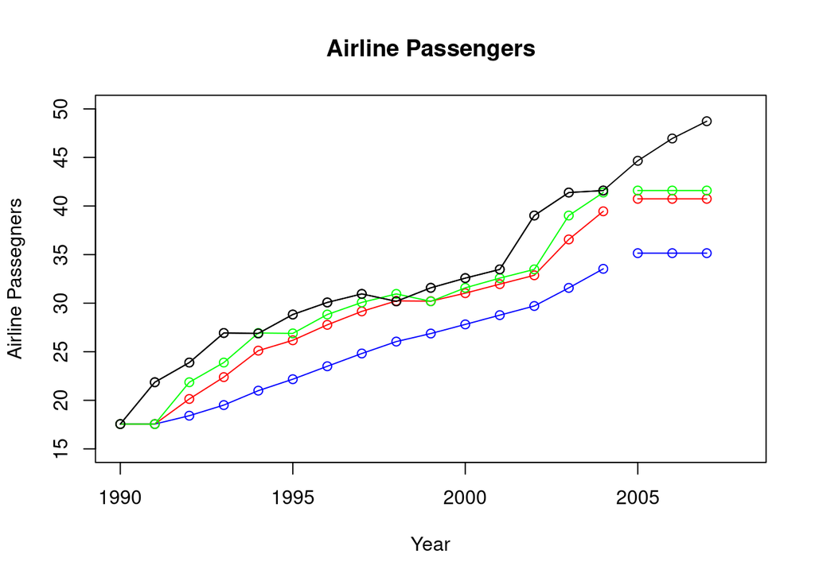

```r
#Reset the plot
plot(air,ylab = "Airline Passegners", xlab = "Year", type = "o", xlim = c(1990, 2008),ylim = c(15,50), main = "Airline Passengers")

#Plot the estimated values from the models .. the "fitted" values are the training values.
lines(fitted(fit1), col = "blue", type = "o")
lines(fitted(fit2), col = "red", type = "o")
lines(fitted(fit3), col = "green", type = "o")

# the  $mean values are the forecasts.
lines(fit1$mean, col = "blue", type = "o")
lines(fit2$mean, col = "red", type = "o")
lines(fit3$mean, col = "green", type = "o")

# These are the actual values!  Compare visually with the forecasts!
air2008 = window(ausair, start = 1990, end = 2007)
points(air2008, type = "o")
```

```r
# Compare the forecasts with the actual values with various fit metrics.
accuracy(fit1, air2008)
```

```
##                     ME      RMSE       MAE      MPE     MAPE     MASE
## Training set  5.864549  6.301705  5.864549 18.74164 18.74164 3.199632
## Test set     11.632265 11.751057 11.632265 24.77018 24.77018 6.346433
##                      ACF1 Theil's U
## Training set  0.405609699        NA
## Test set     -0.003569265  6.140567
```

```r
accuracy(fit2, air2008)
```

```
##                    ME     RMSE      MAE       MPE      MAPE     MASE
## Training set 2.576335 3.101549 2.582686  8.507273  8.528313 1.409084
## Test set     6.038897 6.264665 6.038897 12.797965 12.797965 3.294755
##                      ACF1 Theil's U
## Training set  0.206215181        NA
## Test set     -0.003569265  3.443693
```

```r
accuracy(fit3, air2008)
```

```
##                    ME     RMSE      MAE       MPE      MAPE      MASE
## Training set 1.602998 2.290962 1.710834  5.406487  5.766099 0.9334119
## Test set     5.182781 5.444168 5.182781 10.965507 10.965507 2.8276672
##                      ACF1 Theil's U
## Training set -0.085328673        NA
## Test set     -0.003569265  3.032778
```

```r
summary(fit1)
```

```
##
## Forecast method: Simple exponential smoothing
##
## Model Information:
## Simple exponential smoothing
##
## Call:
##  ses(y = air, h = 3, initial = "simple", alpha = 0.2)
##
##   Smoothing parameters:
##     alpha = 0.2
##
##   Initial states:
##     l = 17.5534
##
##   sigma:  6.3017
## Error measures:
##                    ME     RMSE      MAE      MPE     MAPE     MASE      ACF1
## Training set 5.864549 6.301705 5.864549 18.74164 18.74164 3.199632 0.4056097
##
## Forecasts:
##      Point Forecast    Lo 80    Hi 80    Lo 95    Hi 95
## 2005       35.14705 27.07109 43.22301 22.79593 47.49816
## 2006       35.14705 26.91115 43.38294 22.55133 47.74276
## 2007       35.14705 26.75426 43.53983 22.31139 47.98270
```

Activity Two: Holt Linear (1 hour) Next, this is similar code with a different model (Holt with linear trend.) Again, run this code and get a feel for what it is doing. Feel free to change it up and just learn by playing.

```r
#2 Holt's Linear Trend Model for AUS AIR
fit1h = holt(air, alpha = .8, beta = .2, initial = "simple", h = 5)
fit2h = holt(air, alpha = .8, beta = .2, initial = "simple", exponential = TRUE, h = 5)

# Check out estiamted values of the "training" data from the first holt model
fitted(fit1h)
```

```
## Time Series:
## Start = 1990
## End = 2004
## Frequency = 1
##  [1] 21.86010 22.03237 25.48462 27.54059 30.28813 30.26106 31.58122 32.59923
##  [9] 33.24224 32.26755 33.07776 33.95807 34.77708 40.05535 43.21586
```

```r
# Check out the forecast value (h of them)
fit1h$mean
```

```
## Time Series:
## Start = 2005
## End = 2009
## Frequency = 1
## [1] 43.75697 45.59352 47.43008 49.26663 51.10319
```

```r
# Reset the Plot!
plot(air,ylab = "Airline Passegners", xlab = "Year", type = "o", xlim = c(1990, 2009),ylim = c(15,60))
#Plot each models estimated values of the training data (Do these one by one to see the differences)
lines(fitted(fit1h),col = "blue", type= "o")
lines(fitted(fit2h), col = "red", type= "o")
#Plot each models forecasts (Do these one by one to see the differences)
lines(fit1h$mean, col = "blue", type= "o")
lines(fit2h$mean,col = "red", type= "o")

# Fit another model ... damped!
fit3h = holt(air, alpha = .8, beta = .2, damped = TRUE, initial = "optimal", h = 5)
# Plot the fitted value (estimated from triaining data)
lines(fitted(fit3h), col = "darkgreen", type= "o")
# Plot the forecasts
lines(fit3h$mean,col = "darkgreen", type= "o")

# Fit another model ... what is the difference?
fit4h = holt(air, alpha = .8, beta = .2, damped = TRUE, initial = "optimal", exponential = TRUE, h = 5)
# Plot the fitted value (estimated from triaining data)
lines(fitted(fit4h), col = "cyan", type= "o")
#Plot the forecasts
lines(fit4h$mean,col = "cyan", type= "o")

# with implicit Test set... it figures out by the time which are training and which are test.
accuracy(fit1h, ausair)
```

```
##                      ME     RMSE      MAE       MPE     MAPE      MASE
## Training set -1.0292272 2.202869 1.772637 -4.485612 6.364749 0.9671310
## Test set      0.9405879 1.444776 1.371076  1.947628 2.808140 0.7480438
##                    ACF1 Theil's U
## Training set  0.2088940        NA
## Test set     -0.3313068 0.7212626
```

```r
accuracy(fit2h, ausair)
```

```
##                     ME     RMSE      MAE       MPE     MAPE     MASE      ACF1
## Training set -2.010092 2.908422 2.565680 -7.724285 9.137707 1.399806 0.3109081
## Test set     -1.836519 2.883708 1.859959 -3.672580 3.725068 1.014773 0.1029680
##              Theil's U
## Training set        NA
## Test set      1.403487
```

```r
accuracy(fit3h, ausair)
```

```
##                     ME     RMSE      MAE       MPE     MAPE     MASE      ACF1
## Training set 0.3317307 1.653933 1.084962 0.7156323 3.371681 0.591943 0.1675855
## Test set     3.8715783 4.131618 3.871578 7.8802382 7.880238 2.112290 0.2453622
##              Theil's U
## Training set        NA
## Test set      2.086233
```

```r
#with explicit Test set ... (same output)
airTest = window(ausair, start = 2005)
accuracy(fit1h, airTest)
```

```
##                      ME     RMSE      MAE       MPE     MAPE      MASE
## Training set -1.0292272 2.202869 1.772637 -4.485612 6.364749 0.9671310
## Test set      0.9405879 1.444776 1.371076  1.947628 2.808140 0.7480438
##                    ACF1 Theil's U
## Training set  0.2088940        NA
## Test set     -0.3313068 0.7212626
```

```r
accuracy(fit2h, airTest)
```

```
##                     ME     RMSE      MAE       MPE     MAPE     MASE      ACF1
## Training set -2.010092 2.908422 2.565680 -7.724285 9.137707 1.399806 0.3109081
## Test set     -1.836519 2.883708 1.859959 -3.672580 3.725068 1.014773 0.1029680
##              Theil's U
## Training set        NA
## Test set      1.403487
```

```r
accuracy(fit3h, airTest)
```

```
##                     ME     RMSE      MAE       MPE     MAPE     MASE      ACF1
## Training set 0.3317307 1.653933 1.084962 0.7156323 3.371681 0.591943 0.1675855
## Test set     3.8715783 4.131618 3.871578 7.8802382 7.880238 2.112290 0.2453622
##              Theil's U
## Training set        NA
## Test set      2.086233
```

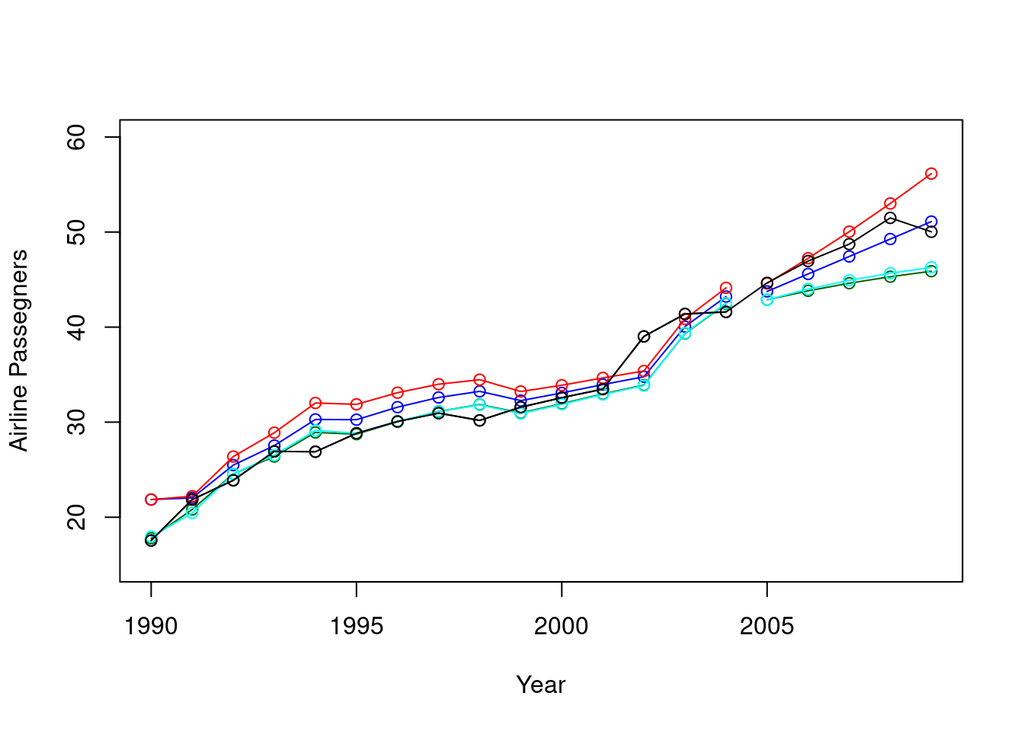

```r
#Add the actual values to visually compare forecasts to actual values
air2008 = window(ausair, start = 1990, end = 2009)
points(air2008, type = "o")
```

Activity Three: Holt Seasonal (1 hour) We are changing the data this time. Still just learn by playing with the code and looking closely at the input arguments and the output. Also, record any questions that pop up while you are playing. We can discuss them in live session.

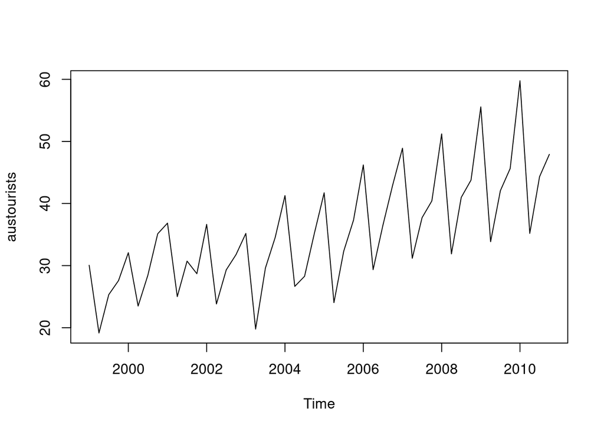

```r
#3. Seasonal Trend

#Load the data
data("austourists")
# Read about the dataset!
?austourists
#1999~2010

# Always plot the data first!
plot(austourists)
```

```r
# returns a ts object.
aust = window(austourists,start = 1999, end = 2004)

#fit an additive and multiplicative model
fit1s = hw(aust,seasonal = "additive",h = 40)
fit2s = hw(aust,seasonal = "multiplicative",h = 40)

#Plot the original data
plot(aust,ylab = "Australian Tourists", xlab = "Year", type = "o", xlim = c(1999, 2014),ylim = c(15,60))
#add the fitted values from the model (of the training data)
lines(fitted(fit1s),col = "blue", type= "o")
lines(fitted(fit2s), col = "red", type= "o")

#Now add the forecasts (add these one at a time)
lines(fit1s$mean, col = "blue", type= "o")
lines(fit2s$mean,col = "red", type= "o")

#Compare the accuracy
accuracy(fit1s,austourists)
```

```
##                      ME     RMSE      MAE        MPE      MAPE      MASE
## Training set -0.4377946 2.266717 1.882623  -1.842903  6.492401 0.6090876
## Test set     -5.0401911 6.019319 5.172738 -14.174410 14.398562 1.6735428
##                     ACF1 Theil's U
## Training set -0.04231276        NA
## Test set     -0.13264014 0.5996539
```

```r
accuracy(fit2s,austourists)
```

```
##                      ME     RMSE      MAE        MPE     MAPE      MASE
## Training set 0.07223675 2.180841 1.626375 -0.1303281 5.531772 0.5261833
## Test set     0.88033413 2.627779 1.933411  1.3152869 4.865291 0.6255191
##                    ACF1 Theil's U
## Training set 0.09930429        NA
## Test set     0.26125025 0.2670124
```

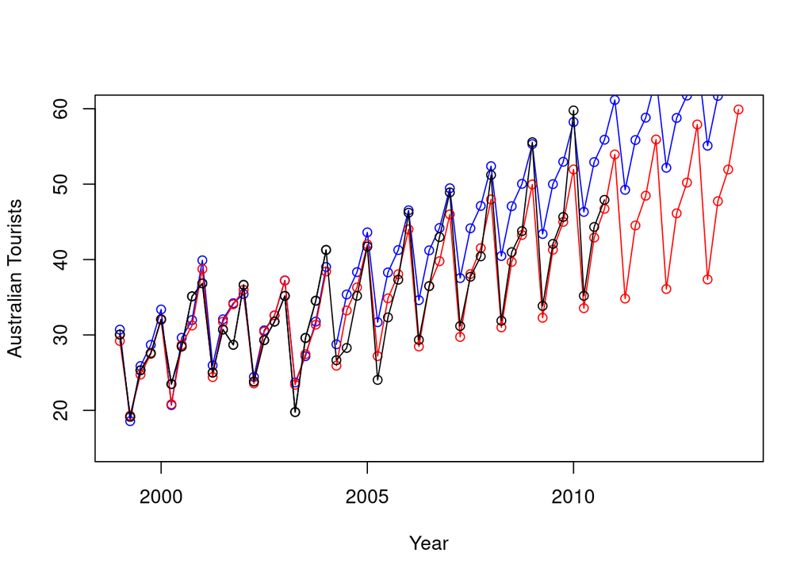

```r
#add the actual values to visually compare the forecasts to the actual values.
points(austourists, type = "o")
```

```r
summary(fit1s)
```

```
##
## Forecast method: Holt-Winters' additive method
##
## Model Information:
## Holt-Winters' additive method
##
## Call:
##  hw(y = aust, h = 40, seasonal = "additive")
##
##   Smoothing parameters:
##     alpha = 0.7359
##     beta  = 0.0303
##     gamma = 1e-04
##
##   Initial states:
##     l = 23.7093
##     b = 1.0098
##     s = 1.4497 -0.7834 -6.6559 5.9896
##
##   sigma:  2.8809
##
##      AIC     AICc      BIC
## 116.3049 132.6686 125.7056
##
## Error measures:
##                      ME     RMSE      MAE       MPE     MAPE      MASE
## Training set -0.4377946 2.266717 1.882623 -1.842903 6.492401 0.6090876
##                     ACF1
## Training set -0.04231276
##
## Forecasts:
##         Point Forecast    Lo 80     Hi 80     Lo 95     Hi 95
## 2004 Q2       28.76275 25.07066  32.45483 23.116194  34.40930
## 2004 Q3       35.36670 30.71549  40.01791 28.253286  42.48012
## 2004 Q4       38.33119 32.82837  43.83401 29.915356  46.74702
## 2005 Q1       43.60232 37.30961  49.89502 33.978459  53.22618
## 2005 Q2       31.68845 24.64484  38.73206 20.916178  42.46072
## 2005 Q3       38.29241 30.52425  46.06057 26.412029  50.17278
## 2005 Q4       41.25689 32.78216  49.73162 28.295910  54.21787
## 2006 Q1       46.52802 37.35918  55.69686 32.505488  60.55055
```

[output cut: 17 more lines]

```
## 2010 Q3       52.92092 31.36504  74.47680 19.954053  85.88779
## 2010 Q4       55.88541 33.60812  78.16270 21.815234  89.95558
## 2011 Q1       61.15654 38.15286  84.16021 25.975452  96.33762
## 2011 Q2       49.24267 25.50748  72.97787 12.942822  85.54252
## 2011 Q3       55.84663 31.37490  80.31835 18.420357  93.27289
## 2011 Q4       58.81111 33.59771  84.02451 20.250547  97.37168
## 2012 Q1       64.08224 38.12198  90.04251 24.379441 103.78504
## 2012 Q2       52.16837 25.45593  78.88081 11.315220  93.02153
## 2012 Q3       58.77233 31.30255  86.24210 16.760933 100.78373
## 2012 Q4       61.73682 33.50444  89.96919 18.559119 104.91451
## 2013 Q1       67.00794 38.00768  96.00821 22.655866 111.36002
## 2013 Q2       55.09408 25.32055  84.86761  9.559392 100.62876
## 2013 Q3       61.69803 31.14602  92.25004 14.972764 108.42330
## 2013 Q4       64.66252 33.32672  95.99832 16.738553 112.58648
## 2014 Q1       69.93365 37.80876 102.05854 20.802870 119.06443
```

Activity Four: Full Analysis(3-5 hours) Temperature Data Using the maxtemp dataset granted by loading the fpp2 package, there are maximum annual temperature data in Celsius. For more information, use help(maxtemp). To see what you’re looking at, execute the command in ‘Examples’ in the help document.

```r
#install.packages("fpp2")
library(fpp2)
```

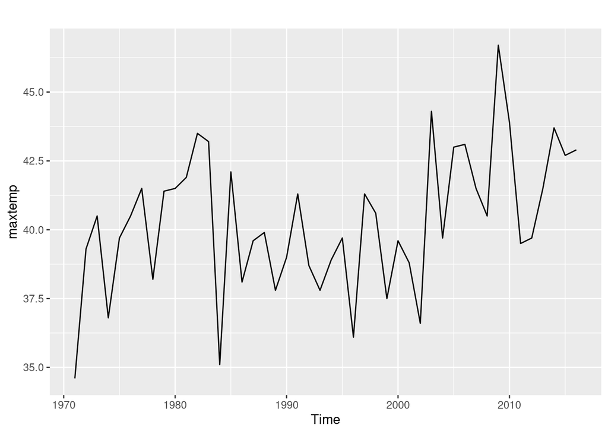

```r
#Load the data
data("maxtemp")
# Read about the dataset!
?maxtemp
#1971 to 2016

#plot
autoplot(maxtemp)
```

We are only concerned with information after 1990. Please eliminate unwanted information or subset information we don’t care about.

```r
hello_subset=window(maxtemp, start = 1990, end=2011)
hello_subset
```

```
## Time Series:
## Start = 1990
## End = 2011
## Frequency = 1
## 1990 1991 1992 1993 1994 1995 1996 1997 1998 1999 2000 2001 2002 2003 2004 2005
## 39.0 41.3 38.7 37.8 38.9 39.7 36.1 41.3 40.6 37.5 39.6 38.8 36.6 44.3 39.7 43.0
## 2006 2007 2008 2009 2010 2011
## 43.1 41.5 40.5 46.7 43.9 39.5
```

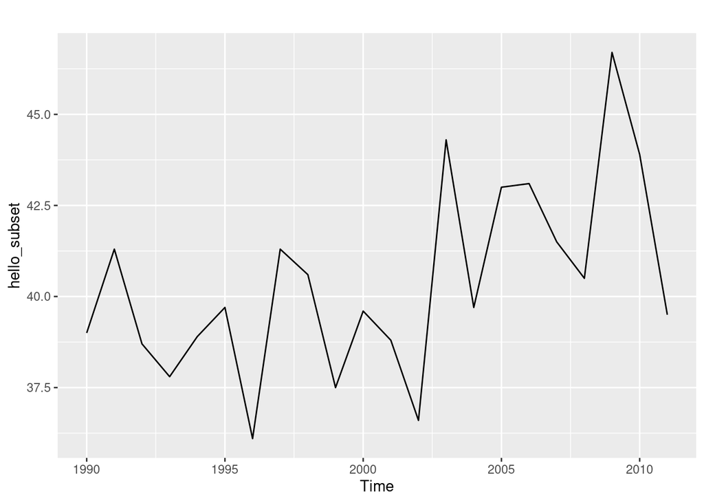

```r
autoplot(hello_subset)
```

```r
#fit 3 different simple exponential smoothing models ... how are they different?
# what does the h paramter do?


hello_fit = ses(hello_subset,alpha = .2,h = 5)
#fit1 = ses(air, initial = "simple",alpha = .2,h = 3)
#fit2 = ses(air,initial = "simple",alpha = .6, h = 3)
#fit3 = ses(air, h = 3) #defaults

# the forecast package has a nice accuracy funciton with various metrics just pass it the
# the model and the data!  (This is the "training" data)
accuracy(hello_fit, maxtemp)
```

```
##                     ME     RMSE      MAE      MPE     MAPE      MASE       ACF1
## Training set 0.5662618 2.473689 1.905179 1.070668 4.619739 0.7006787 -0.1713356
## Test set     0.2416879 1.412237 1.248338 0.462755 2.982738 0.4591084  0.1983471
##              Theil's U
## Training set        NA
## Test set     0.7466621
```

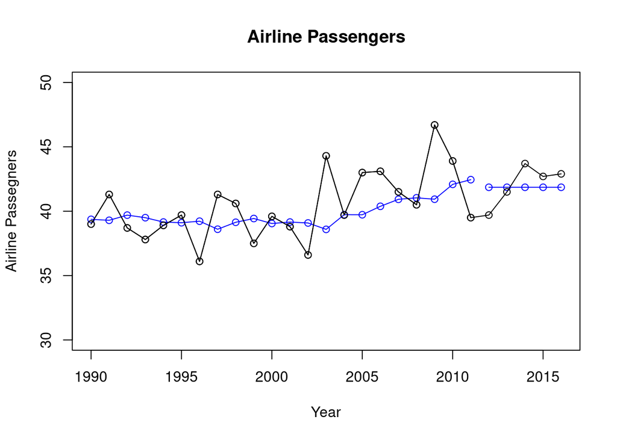

```r
#Reset the plot
plot(hello_subset,ylab = "Airline Passegners", xlab = "Year", type = "o", xlim = c(1990, 2016),ylim = c(30,50), main = "Airline Passengers")

#Plot the estimated values from the models .. the "fitted" values are the training values.
lines(fitted(hello_fit), col = "blue", type = "o")


# the  $mean values are the forecasts.
lines(hello_fit$mean, col = "blue", type = "o")


# These are the actual values!  Compare visually with the forecasts!
air2016 = window(maxtemp, start = 1990, end = 2016)
points(air2016, type = "o")
```

```r
accuracy(hello_fit, air2016)
```

```
##                     ME     RMSE      MAE      MPE     MAPE      MASE       ACF1
## Training set 0.5662618 2.473689 1.905179 1.070668 4.619739 0.7006787 -0.1713356
## Test set     0.2416879 1.412237 1.248338 0.462755 2.982738 0.4591084  0.1983471
##              Theil's U
## Training set        NA
## Test set     0.7466621
```

```r
hello_air = hello_subset
#2 Holt's Linear Trend Model for AUS AIR
hello_fit1h = holt(hello_subset, alpha = .4, beta = .1, h = 5)
#fit1h = holt(air, alpha = .8, beta = .2, initial = "simple", h = 5)
#fit2h = holt(air, alpha = .8, beta = .2, initial = "simple", exponential = TRUE, h = 5)



# Check out estiamted values of the "training" data from the first holt model
fitted(hello_fit1h)
```

```
## Time Series:
## Start = 1990
## End = 2011
## Frequency = 1
##  [1] 39.36389 39.05099 40.00815 39.41163 38.53256 38.48186 38.89325 37.42076
##  [9] 39.00519 39.83533 38.85988 39.18862 39.02701 37.80734 40.80480 40.65280
## [17] 42.11632 43.13280 42.93941 42.17943 44.65550 44.94559
```

```r
# Check out the forecast value (h of them)
hello_fit1h$mean
```

```
## Time Series:
## Start = 2012
## End = 2016
## Frequency = 1
## [1] 42.81509 42.86282 42.91056 42.95829 43.00603
```

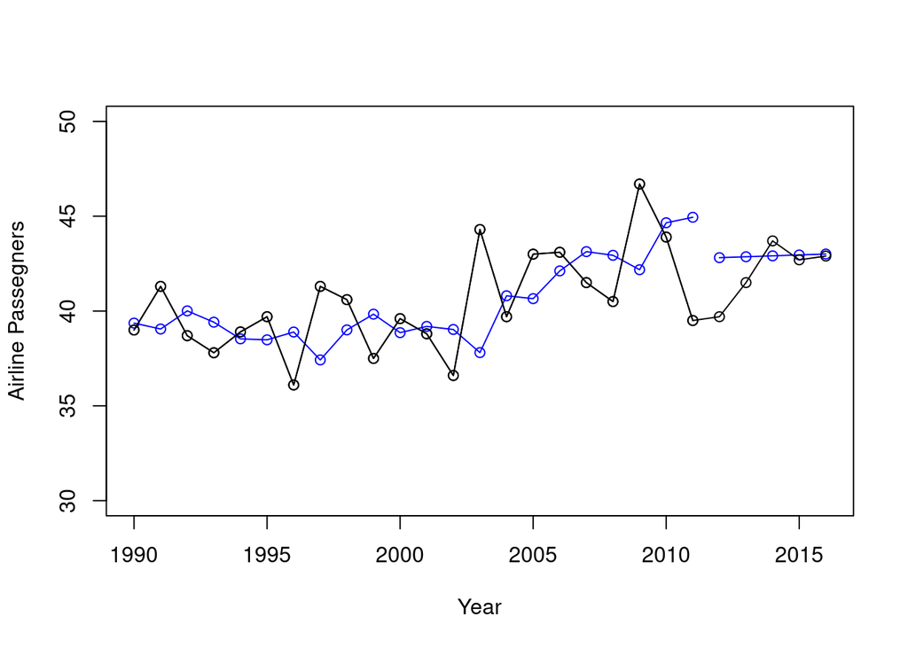

```r
# Reset the Plot!
plot(hello_subset,ylab = "Airline Passegners", xlab = "Year", type = "o", xlim = c(1990, 2016),ylim = c(30,50))
#Plot each models estimated values of the training data (Do these one by one to see the differences)
lines(fitted(hello_fit1h),col = "blue", type= "o")

#Plot each models forecasts (Do these one by one to see the differences)
lines(hello_fit1h$mean, col = "blue", type= "o")

# These are the actual values!  Compare visually with the forecasts!
air2016 = window(maxtemp, start = 1990, end = 2016)
points(air2016, type = "o")
```

```r
summary(hello_fit1h)
```

```
##
## Forecast method: Holt's method
##
## Model Information:
## Holt's method
##
## Call:
##  holt(y = hello_subset, h = 5, alpha = 0.4, beta = 0.1)
##
##   Smoothing parameters:
##     alpha = 0.4
##     beta  = 0.1
##
##   Initial states:
##     l = 39.4948
##     b = -0.131
##
##   sigma:  2.9598
##
##      AIC     AICc      BIC
## 117.3332 118.6665 120.6063
##
## Error measures:
##                      ME     RMSE      MAE         MPE     MAPE      MASE
## Training set 0.08122211 2.677218 2.136312 -0.07713968 5.234001 0.7856838
##                    ACF1
## Training set -0.2947581
##
## Forecasts:
##      Point Forecast    Lo 80    Hi 80    Lo 95    Hi 95
## 2012       42.81509 39.02199 46.60820 37.01404 48.61614
## 2013       42.86282 38.62200 47.10364 36.37705 49.34860
## 2014       42.91056 38.09765 47.72347 35.54985 50.27127
## 2015       42.95829 37.46156 48.45502 34.55177 51.36482
## 2016       43.00603 36.72732 49.28473 33.40357 52.60848
```

Compare the AICc and BIC of the ses() and holt() models. Which model is better here?

```r
#ses()
hello_fit$model
```

```
## Simple exponential smoothing
##
## Call:
##  ses(y = hello_subset, h = 5, alpha = 0.2)
##
##   Smoothing parameters:
##     alpha = 0.2
##
##   Initial states:
##     l = 39.3668
##
##   sigma:  2.5944
##
##      AIC     AICc      BIC
## 111.8542 112.4858 114.0363
```

```r
#holt()
hello_fit1h$model
```

```
## Holt's method
##
## Call:
##  holt(y = hello_subset, h = 5, alpha = 0.4, beta = 0.1)
##
##   Smoothing parameters:
##     alpha = 0.4
##     beta  = 0.1
##
##   Initial states:
##     l = 39.4948
##     b = -0.131
##
##   sigma:  2.9598
##
##      AIC     AICc      BIC
## 117.3332 118.6665 120.6063
```

```r
#the mean absolute error of the forecast values
summary(hello_fit)
```

```
##
## Forecast method: Simple exponential smoothing
##
## Model Information:
## Simple exponential smoothing
##
## Call:
##  ses(y = hello_subset, h = 5, alpha = 0.2)
##
##   Smoothing parameters:
##     alpha = 0.2
##
##   Initial states:
##     l = 39.3668
##
##   sigma:  2.5944
##
##      AIC     AICc      BIC
## 111.8542 112.4858 114.0363
##
## Error measures:
##                     ME     RMSE      MAE      MPE     MAPE      MASE       ACF1
## Training set 0.5662618 2.473689 1.905179 1.070668 4.619739 0.7006787 -0.1713356
##
## Forecasts:
##      Point Forecast    Lo 80    Hi 80    Lo 95    Hi 95
## 2012       41.85831 38.53342 45.18320 36.77333 46.94330
## 2013       41.85831 38.46757 45.24905 36.67263 47.04400
## 2014       41.85831 38.40298 45.31364 36.57384 47.14278
## 2015       41.85831 38.33958 45.37705 36.47687 47.23975
## 2016       41.85831 38.27729 45.43933 36.38162 47.33501
```

```r
summary(hello_fit1h)
```

```
##
## Forecast method: Holt's method
##
## Model Information:
## Holt's method
##
## Call:
##  holt(y = hello_subset, h = 5, alpha = 0.4, beta = 0.1)
##
##   Smoothing parameters:
##     alpha = 0.4
##     beta  = 0.1
##
##   Initial states:
##     l = 39.4948
##     b = -0.131
##
##   sigma:  2.9598
##
##      AIC     AICc      BIC
## 117.3332 118.6665 120.6063
##
## Error measures:
##                      ME     RMSE      MAE         MPE     MAPE      MASE
## Training set 0.08122211 2.677218 2.136312 -0.07713968 5.234001 0.7856838
##                    ACF1
## Training set -0.2947581
##
## Forecasts:
##      Point Forecast    Lo 80    Hi 80    Lo 95    Hi 95
## 2012       42.81509 39.02199 46.60820 37.01404 48.61614
## 2013       42.86282 38.62200 47.10364 36.37705 49.34860
## 2014       42.91056 38.09765 47.72347 35.54985 50.27127
## 2015       42.95829 37.46156 48.45502 34.55177 51.36482
## 2016       43.00603 36.72732 49.28473 33.40357 52.60848
```

Bonus: The Wands Chooses the Wizard We will cover this in Live Session… get a head start if you have time! Utilize the dygraphs library. Read in both Unit12TimeSeries_Ollivander and _Gregorovitch.csv as two different data frames. They do not have headers, so make sure you account for that. This is a time series of Wands sold over years.

```r
hello_greg = read.csv("Unit11TimeSeries_Gregorovitch.csv")
hello_olli = read.csv("Unit11TimeSeries_Ollivander.csv")
```

You don’t have your information in the proper format! In both data sets, you’ll need to first convert the date-like variable to an actual Date class.

Use the library xts (and the xts() function in it) to make each data frame an xts object (effectively, a time series). You’ll want to order.by the Date variable.

```r
library("xts")

greg <- xts(hello_greg[,-1], order.by=as.Date(hello_greg[,1], "%m/%d/%Y"))
olli <- xts(hello_olli[,-1], order.by=as.Date(hello_olli[,1], "%m/%d/%Y"))
```

Bind the two xts objects together and create a dygraph from it. Utilize the help() index if you’re stuck.

Give an effective title and x/y axes.

Label each Series (via dySeries) to be the appropriate wand-maker. So, one line should create a label for Ollivander and the other for Gregorovitch.

Stack this graph and modify the two lines to be different colors (and not the default ones!) Any colors are fine, but make sure they’re visible and that Ollivander is a different color than Gregorovitch.

Activate a range selector and make it big enough to view.

Use dyShading to illuminate approximately when Voldemort was revived and at-large: between 1995 to 1999.

Enable Highlighting on the graph, so mousing over a line bolds it.

```r
library(dygraphs)
hello_graphs <- cbind(greg, olli)
dygraph(hello_graphs, main = "Magic Wands sold in Diagon Alley",ylab = "Magic Wond sold", xlab = "Year") %>%
  dyShading(from = "1995-01-01", to = "1999-01-01", axis = "x")
```

[interactive chart not shown]